# Desarrollo del Examen Parcial

Ceras Robles, Jose Alexander (código : 17160034)

Condor Melo,Deysy (código : 17160180)

Lara Huapaya, José Alberto (código : 17160206)

Miguel Jurado, Giannina Milagros (código : 17160191)

Ramos Castillo,Jacqueline Elizabeth (código : 17160195)

August, 2021

## Parte 01

**1.1** *Se tiene una variable x (no necesariamente temperatura) que depende de la elevación. Se sabe que entre los 1000 y 3000 metros, esta variable se ve reducido en 2 unidades cada 500 metros. Entre los 3000 y 4000 metros, varía en 0.5 unidades, y a una altitud mayor, su valor es constante. Cree una función que permita obtener el valor de esta variable, unicamente con el dato de la elevación.*

`El valor de la variable x a 1000 metros es de 81.4 unidades`

Crearemos una función que determine el valor de la variable a partir de la altura:

```r
Variable<- function(altura){
  Variable = 81.4
  if (altura > 1000 & altura <= 3000){
    Efecto =  Variable - (2 * (altura - Variable)/500)

  } else if
    (altura > 3000 & altura <= 4000){
    Efecto = Variable - (0.5 * (altura - Variable)/500)

  } else {
    Efecto = Variable
  }
  return(Efecto)
}
```

Evaluando para valores de alturas aleatorias:

```r
Variable(1000)
```

```
## [1] 81.4
```

```r
Variable(2500)
```

```
## [1] 71.7256
```

```r
Variable(3500)
```

```
## [1] 77.9814
```

```r
Variable(4500)
```

```
## [1] 81.4
```

**1.2** *Resolver el sistema de ecuaciones*

$$\left.\begin{array}{l}
3a+2b-2c=0\\
2a-1b+3c=9\\
a+4b+2c=-4
\end{array}\right\}$$
`Mediante el uso de matrices`

**Primer método: Operaciones filas**

Como primer paso crearemos las matrices “A” y “B”:

$$\begin{pmatrix}
3 & 2 & -2 \\
2 & -1 & 3 \\
1 & 4 & 2 \\
\end{pmatrix}$$
$$\begin{pmatrix}
a \\
b \\
c \\
\end{pmatrix}$$
=
$$\begin{pmatrix}
0 \\
9 \\
-4 \\
\end{pmatrix}$$

Creación de la matriz A:

```r
A <- matrix(c(3,2,-2,2,-1,3,1,4,2),3,3,byrow=T)
A
```

```
##      [,1] [,2] [,3]
## [1,]    3    2   -2
## [2,]    2   -1    3
## [3,]    1    4    2
```

Creación de la matriz B:

```r
B <- matrix(c(0,9,-4),3,1)
B
```

```
##      [,1]
## [1,]    0
## [2,]    9
## [3,]   -4
```

Por consiguiente, concatenaremos las matrices “A” y “B” para obtener una nueva matriz denominada “AB”:

```r
AB <- cbind(A,B)
AB
```

```
##      [,1] [,2] [,3] [,4]
## [1,]    3    2   -2    0
## [2,]    2   -1    3    9
## [3,]    1    4    2   -4
```

Para hallar a, b, c es necesario que las tres primeras columnas formen una matriz identidad de 3 x 3. La última columna representará el vector de soluciones. Para llegar a dicha solución, se realizarán las operaciones en fila:

Como primera operación, se debe obtener la unidad en el primer elemento de la fila 1, para eso dividimos toda la primera fila entre 3:

```r
AB[1,] <- AB[1,]/3
AB
```

```
##      [,1]       [,2]       [,3] [,4]
## [1,]    1  0.6666667 -0.6666667    0
## [2,]    2 -1.0000000  3.0000000    9
## [3,]    1  4.0000000  2.0000000   -4
```

Aplicando la misma lógica, para obtener que toda la primera columna tenga la unidad, se debe dividir dichos elementos entre su misma cantidad:

```r
AB[2,] <- AB[2,]/2
AB
```

```
##      [,1]       [,2]       [,3] [,4]
## [1,]    1  0.6666667 -0.6666667  0.0
## [2,]    1 -0.5000000  1.5000000  4.5
## [3,]    1  4.0000000  2.0000000 -4.0
```

El siguiente paso es obtener un valor “cero” en la posición [2,1], para esto restamos la segunda fila con la primera fila:

```r
AB[2,] <- AB[2,]-AB[1,]
AB
```

```
##      [,1]       [,2]       [,3] [,4]
## [1,]    1  0.6666667 -0.6666667  0.0
## [2,]    0 -1.1666667  2.1666667  4.5
## [3,]    1  4.0000000  2.0000000 -4.0
```

De igual forma, para obtener un valor “cero” en la posición [3,1], se tiene que restar tercera fila con la primera fila:

```r
AB[3,] <- AB[3,]-AB[1,]
AB
```

```
##      [,1]       [,2]       [,3] [,4]
## [1,]    1  0.6666667 -0.6666667  0.0
## [2,]    0 -1.1666667  2.1666667  4.5
## [3,]    0  3.3333333  2.6666667 -4.0
```

El siguiente procedimiento será determinar la unidad en la posición de la diagonal principal de la matriz para formar la matriz identidad, para eso dividimos la fila 2 entre el valor de la posición [2,2]:

```r
AB[2,] <- AB[2,]/AB[2,2]
AB
```

```
##      [,1]      [,2]       [,3]      [,4]
## [1,]    1 0.6666667 -0.6666667  0.000000
## [2,]    0 1.0000000 -1.8571429 -3.857143
## [3,]    0 3.3333333  2.6666667 -4.000000
```

Aprovechando el valor de la posición [2,2], se puede utilizar para determinar el valor cero de la posición [3,2], ya que a la segunda fila se le puede multiplicar por dicha posición, con el objetivo de aplicarle una resta y obtener el valor 0 para la posición [3,2]:

```r
AB[3,] <- AB[3,]-(AB[2,]*AB[3,2])
AB
```

```
##      [,1]      [,2]       [,3]      [,4]
## [1,]    1 0.6666667 -0.6666667  0.000000
## [2,]    0 1.0000000 -1.8571429 -3.857143
## [3,]    0 0.0000000  8.8571429  8.857143
```

Luego dividimos la fila 3 entre el valor de la posición [3,3] para hallar la unidad de dicha posición:

```r
AB[3,] <- AB[3,]/AB[3,3]
AB
```

```
##      [,1]      [,2]       [,3]      [,4]
## [1,]    1 0.6666667 -0.6666667  0.000000
## [2,]    0 1.0000000 -1.8571429 -3.857143
## [3,]    0 0.0000000  1.0000000  1.000000
```

Luego para completar el valor “cero” de la posición [2,3], se aprovechará el valor de la unidad de la columna 2, sumando la fila 2 con el producto de la fila 3 con la posición [2,3]:

```r
AB[2,] <- AB[2,]-(AB[3,]*AB[2,3])
AB
```

```
##      [,1]      [,2]       [,3] [,4]
## [1,]    1 0.6666667 -0.6666667    0
## [2,]    0 1.0000000  0.0000000   -2
## [3,]    0 0.0000000  1.0000000    1
```

Aplicando el mismo procedimiento del paso anterior, se puede obtener el valor “cero” en la posición [1,2], aprovechando la unidad de la posición [2,2]:

```r
AB[1,] <- AB[1,]-(AB[2,]*AB[1,2])
AB
```

```
##      [,1] [,2]       [,3]      [,4]
## [1,]    1    0 -0.6666667  1.333333
## [2,]    0    1  0.0000000 -2.000000
## [3,]    0    0  1.0000000  1.000000
```

De la misma manera, se realiza el mismo procedimiento para calcular el valor “cero” de la posición [1,3]:

```r
AB[1,] <- AB[1,]-(AB[3,]*AB[1,3])
AB
```

```
##      [,1] [,2] [,3] [,4]
## [1,]    1    0    0    2
## [2,]    0    1    0   -2
## [3,]    0    0    1    1
```

*Se observa que las tres primeras columnas forman una matriz identidad 3 × 3. Esto quiere decir que la solución es a = 2, b = -2, c = 1.*

```r
R <- AB[,4]
R
```

```
## [1]  2 -2  1
```

**Segundo método: Función solve**

También se puede resolver el sistema usando la función SOLVE: Esta función genérica resuelve la ecuación a% *% x = b para x, donde b puede ser un vector o una matriz.

Para demostrar que la matriz 3 x 3 obtenida es invertible, se le debe aplicar la función “Solve”:

```r
XX <- solve(A,B)
XX
```

```
##      [,1]
## [1,]    2
## [2,]   -2
## [3,]    1
```

Entonces se obtienen los siguientes resultados: a = 2, b = -2 y c = 1

## Parte 02

1. A partir del siguiente conjunto de datos, se describen las variables:
- uh name → Nombre de cuenca
- bh esc → Escenario (observado y modelos climáticos)
- bh month → Meses
- bh pc → Precipitación
- bh er → Evapotranspiración Real
- bh rh → Rendimiento Hídrico
- bh qd → Caudal

En este caso estamos escogiendo la cuenca Tumbes, entonces cargaremos la data:

```r
data<-read.csv("https://raw.githubusercontent.com/betolara98/Programacion-II/master/mods_clima_uh.csv")
head(data)
```

```
##   code       uh_name    bh_esc bh_month      bh_pc     bh_er     bh_rh
## 1 1394 Cuenca Tumbes Observado        1 107.722222 31.494011  34.65572
## 2 1394 Cuenca Tumbes Observado        2 181.995216 50.795865  66.03661
## 3 1394 Cuenca Tumbes Observado        3 227.954012 79.128161  98.19603
## 4 1394 Cuenca Tumbes Observado        4 199.013889 66.466013 111.66843
## 5 1394 Cuenca Tumbes Observado        5  38.984259 23.493009  74.63566
## 6 1394 Cuenca Tumbes Observado        6   8.394444  7.102611  46.13475
##       bh_qd
## 1  62.12648
## 2 138.46183
## 3 190.21704
## 4 224.75790
## 5 157.27637
## 6 102.03340
```

Como segundo paso vamos a cargar las librerías usadas:

`Instalar las librerias`

```r
library(dplyr)
```

```r
library(stringr)
library(tidyr)
library(ggplot2)
library(ggthemes)
```

Ubicamos nuestra cuenca y seleccionamos las precipitaciones correspondientes con sus respectivos meses y escenarios:

```r
datos<-data %>% dplyr::filter(uh_name=="Cuenca Tumbes") %>%
  rename(Cuenca=uh_name,
         Escenario=bh_esc,
         Meses=bh_month,
         Precipitacion=bh_pc,
         ETR=bh_er,
         Rendimientoh=bh_rh,
         Caudal=bh_qd)
head(datos)
```

```
##   code        Cuenca Escenario Meses Precipitacion       ETR Rendimientoh
## 1 1394 Cuenca Tumbes Observado     1    107.722222 31.494011     34.65572
## 2 1394 Cuenca Tumbes Observado     2    181.995216 50.795865     66.03661
## 3 1394 Cuenca Tumbes Observado     3    227.954012 79.128161     98.19603
## 4 1394 Cuenca Tumbes Observado     4    199.013889 66.466013    111.66843
## 5 1394 Cuenca Tumbes Observado     5     38.984259 23.493009     74.63566
## 6 1394 Cuenca Tumbes Observado     6      8.394444  7.102611     46.13475
##      Caudal
## 1  62.12648
## 2 138.46183
## 3 190.21704
## 4 224.75790
## 5 157.27637
## 6 102.03340
```

Se solicita lo siguiente:

**2.1** *Calcular la precipitación acumulada anual (Valores observados) para la cuenca asignada.*

Hallamos la precipitacion acumulada anual de los datos observados:

```r
PPAcumuladaAnual<- datos %>% select(2:5) %>%
  filter(Escenario=="Observado") %>% summarize(Precipitación=sum(Precipitacion,na.rm = T))

colnames(PPAcumuladaAnual) <- "Precipitación acumulada anual"
PPAcumuladaAnual
```

```
##   Precipitación acumulada anual
## 1                      851.8519
```

**2.2** *Calcular el porcentaje de sesgo (%, PBIAS) de los escenarios climáticos (ACCESS, HADGEM2, MPI) respecto a los datos observados para cada mes (enero - diciembre) de cada variable, para la cuenca asignada.*

Para obtenerlo se utilizará las precipitaciones del escenerio observado, entonces para un mejor entendimiento, utilizaremos la siguiente función:

- Spreat: La función spread es usada cuando tenemos una observación dispersa en múltiples filas. Te ayuda a estructurar de fila a columna.

Opcional:

- Gather: La función gather toma múltiples columnas y las une en pares clave-valor. Te ayuda a estructurar de columna a fila.

La fórmula que se utilizará para calcular el porcentaje de sesgo es el siguiente:

$$PBIAS = \frac{(ESCENARIO - OBSERVADO)}{OBSERVADO}*100$$
Luego crearemos las columnas que contengan el porcentaje de sesgo (%, PBIAS) de los escenarios climáticos (ACCESS, HADGEM2, MPI) respecto a los datos observados para cada mes (enero - diciembre) de cada variable:

**Precipitación**

```r
Sesgo_p<-datos %>% tibble() %>% select(1:4,Precipitacion) %>%
  spread(key = Escenario, value = Precipitacion) %>%
  mutate(Meses = month.abb) %>%
  mutate(Meses = factor(Meses,levels=month.abb)) %>%
  mutate(SesgoACCES1.0 = ((`ACCESS 1.0`- Observado) / Observado)*100,
         SesgoHadGEM2_ES = ((`HadGEM2-ES` - Observado) / Observado)*100,
         SesgoMPI_ESM_LR = ((`MPI-ESM-LR` - Observado) / Observado)*100)

Sesgo_p
```

```
## # A tibble: 12 x 10
##     code Cuenca        Meses `ACCESS 1.0` `HadGEM2-ES` `MPI-ESM-LR` Observado
##    <int> <chr>         <fct>        <dbl>        <dbl>        <dbl>     <dbl>
##  1  1394 Cuenca Tumbes Jan        189.         106.          88.2     108.
##  2  1394 Cuenca Tumbes Feb        225.         221.         233.      182.
##  3  1394 Cuenca Tumbes Mar        293.         244.         230.      228.
##  4  1394 Cuenca Tumbes Apr        218.         227.         148.      199.
##  5  1394 Cuenca Tumbes May         32.2         66.5         33.1      39.0
##  6  1394 Cuenca Tumbes Jun          7.58        11.8          4.08      8.39
##  7  1394 Cuenca Tumbes Jul          2.68         3.53         0.843     1.11
##  8  1394 Cuenca Tumbes Aug          0.473        0.834        0.463     0.621
##  9  1394 Cuenca Tumbes Sep          2.05         1.82         1.59      2.07
## 10  1394 Cuenca Tumbes Oct         24.0         13.0         19.3      13.4
## 11  1394 Cuenca Tumbes Nov         28.3         26.8         37.2      28.1
## 12  1394 Cuenca Tumbes Dec         49.9         47.2         43.4      42.5
## # ... with 3 more variables: SesgoACCES1.0 <dbl>, SesgoHadGEM2_ES <dbl>,
## #   SesgoMPI_ESM_LR <dbl>
```

**Evapotranspiración Real**

```r
Sesgo_etr<-datos %>% tibble() %>% select(1:4,ETR) %>%
  spread(key = Escenario, value = ETR) %>%
  mutate(Meses = month.abb) %>%
  mutate(Meses = factor(Meses,levels=month.abb)) %>%
  mutate(SesgoACCES1.0 = ((`ACCESS 1.0`- Observado) / Observado)*100,
         SesgoHadGEM2_ES = ((`HadGEM2-ES` - Observado) / Observado)*100,
         SesgoMPI_ESM_LR = ((`MPI-ESM-LR` - Observado) / Observado)*100)

Sesgo_etr
```

```
## # A tibble: 12 x 10
##     code Cuenca        Meses `ACCESS 1.0` `HadGEM2-ES` `MPI-ESM-LR` Observado
##    <int> <chr>         <fct>        <dbl>        <dbl>        <dbl>     <dbl>
##  1  1394 Cuenca Tumbes Jan         37.4          31.8        30.0      31.5
##  2  1394 Cuenca Tumbes Feb         56.5          55.8        56.2      50.8
##  3  1394 Cuenca Tumbes Mar         85.1          82.4        81.2      79.1
##  4  1394 Cuenca Tumbes Apr         67.8          69.7        62.2      66.5
##  5  1394 Cuenca Tumbes May         20.5          27.6        20.2      23.5
##  6  1394 Cuenca Tumbes Jun          6.54          9.45        4.62      7.10
##  7  1394 Cuenca Tumbes Jul          2.95          4.10        1.40      1.89
##  8  1394 Cuenca Tumbes Aug          0.960         1.64        0.840     0.927
##  9  1394 Cuenca Tumbes Sep          2.20          2.25        1.75      2.10
## 10  1394 Cuenca Tumbes Oct         16.5          10.9        14.2      10.5
## 11  1394 Cuenca Tumbes Nov         17.2          16.1        19.6      16.2
## 12  1394 Cuenca Tumbes Dec         21.5          20.5        20.4      19.5
## # ... with 3 more variables: SesgoACCES1.0 <dbl>, SesgoHadGEM2_ES <dbl>,
## #   SesgoMPI_ESM_LR <dbl>
```

**Rendimiento hídrico**

```r
Sesgo_rh<-datos %>% tibble() %>% select(1:4,Rendimientoh) %>%
  spread(key = Escenario, value = Rendimientoh) %>%
  mutate(Meses = month.abb) %>%
  mutate(Meses = factor(Meses,levels=month.abb)) %>%
  mutate(SesgoACCES1.0 = ((`ACCESS 1.0`- Observado) / Observado)*100,
         SesgoHadGEM2_ES = ((`HadGEM2-ES` - Observado) / Observado)*100,
         SesgoMPI_ESM_LR = ((`MPI-ESM-LR` - Observado) / Observado)*100)

Sesgo_rh
```

```
## # A tibble: 12 x 10
##     code Cuenca        Meses `ACCESS 1.0` `HadGEM2-ES` `MPI-ESM-LR` Observado
##    <int> <chr>         <fct>        <dbl>        <dbl>        <dbl>     <dbl>
##  1  1394 Cuenca Tumbes Jan           65.5         34.8         29.6      34.7
##  2  1394 Cuenca Tumbes Feb          102.          78.7         81.5      66.0
##  3  1394 Cuenca Tumbes Mar          141.         114.         107.       98.2
##  4  1394 Cuenca Tumbes Apr          144.         129.          95.6     112.
##  5  1394 Cuenca Tumbes May           92.0         93.2         65.1      74.6
##  6  1394 Cuenca Tumbes Jun           56.3         57.1         41.5      46.1
##  7  1394 Cuenca Tumbes Jul           40.6         40.2         30.3      33.3
##  8  1394 Cuenca Tumbes Aug           28.7         28.3         21.7      23.7
##  9  1394 Cuenca Tumbes Sep           20.1         19.7         15.2      16.6
## 10  1394 Cuenca Tumbes Oct           17.1         15.5         12.8      13.4
## 11  1394 Cuenca Tumbes Nov           15.3         14.1         14.2      12.9
## 12  1394 Cuenca Tumbes Dec           18.8         17.1         16.2      15.0
## # ... with 3 more variables: SesgoACCES1.0 <dbl>, SesgoHadGEM2_ES <dbl>,
## #   SesgoMPI_ESM_LR <dbl>
```

**Caudal**

```r
Sesgo_caudal<-datos %>% tibble() %>% select(1:4,Caudal) %>%
  spread(key = Escenario, value = Caudal) %>%
  mutate(Meses = month.abb) %>%
  mutate(Meses = factor(Meses,levels=month.abb)) %>%
  mutate(SesgoACCES1.0 = ((`ACCESS 1.0`- Observado) / Observado)*100,
         SesgoHadGEM2_ES = ((`HadGEM2-ES` - Observado) / Observado)*100,
         SesgoMPI_ESM_LR = ((`MPI-ESM-LR` - Observado) / Observado)*100)

Sesgo_caudal
```

```
## # A tibble: 12 x 10
##     code Cuenca        Meses `ACCESS 1.0` `HadGEM2-ES` `MPI-ESM-LR` Observado
##    <int> <chr>         <fct>        <dbl>        <dbl>        <dbl>     <dbl>
##  1  1394 Cuenca Tumbes Jan          120.          66.3         53.8      62.1
##  2  1394 Cuenca Tumbes Feb          232.         176.         170.      138.
##  3  1394 Cuenca Tumbes Mar          283.         227.         207.      190.
##  4  1394 Cuenca Tumbes Apr          301.         263.         197.      225.
##  5  1394 Cuenca Tumbes May          202.         198.         136.      157.
##  6  1394 Cuenca Tumbes Jun          129.         130.          90.1     102.
##  7  1394 Cuenca Tumbes Jul           87.5         86.4         62.3      69.6
##  8  1394 Cuenca Tumbes Aug           60.0         59.2         43.2      48.1
##  9  1394 Cuenca Tumbes Sep           42.0         41.2         30.4      33.8
## 10  1394 Cuenca Tumbes Oct           33.2         30.3         23.5      25.3
## 11  1394 Cuenca Tumbes Nov           29.3         26.9         25.3      23.6
## 12  1394 Cuenca Tumbes Dec           33.6         30.9         28.4      26.2
## # ... with 3 more variables: SesgoACCES1.0 <dbl>, SesgoHadGEM2_ES <dbl>,
## #   SesgoMPI_ESM_LR <dbl>
```

**2.3** *De la pregunta anterior, Cuál es el escenario climático más preciso? Fundamente su respuesta.*

**PRIMER MÉTODO**

**Precipitación**:

Promediando los valores absolutos de los porcentajes de los sesgos calculados para la variable precipitación:

```r
Promedio_Sesgo_p <-Sesgo_p %>%
  summarise(ACCES1.0 = mean(abs(SesgoACCES1.0)),
            HadGEM2_ES = mean(abs(SesgoHadGEM2_ES)),
            MPI_ESM_LR = mean(abs(SesgoMPI_ESM_LR)))

Promedio_Sesgo_p
```

```
## # A tibble: 1 x 3
##   ACCES1.0 HadGEM2_ES MPI_ESM_LR
##      <dbl>      <dbl>      <dbl>
## 1     35.7       36.5       24.2
```

*INTERPRETACIÓN*

Como observamos en los resultados, el que presenta menor porcentaje promedio de sesgo (en valores absolutos) es el escenario climático “MPI-ESM-LR”, siendo el más preciso, ya que con valores de baja magnitud indican una simulación precisa del modelo.

**Evapotranspiración real**: Promediando los valores absolutos de los porcentajes de los sesgos calculados para la variable evapotranspiración real:

```r
Promedio_Sesgo_etr <-Sesgo_etr %>%
  summarise(ACCES1.0 = mean(abs(SesgoACCES1.0)),
            HadGEM2_ES = mean(abs(SesgoHadGEM2_ES)),
            MPI_ESM_LR = mean(abs(SesgoMPI_ESM_LR)))

Promedio_Sesgo_etr
```

```
## # A tibble: 1 x 3
##   ACCES1.0 HadGEM2_ES MPI_ESM_LR
##      <dbl>      <dbl>      <dbl>
## 1     16.4       23.3       15.5
```

*INTERPRETACIÓN*

Como observamos en los resultados, el que presenta menor porcentaje promedio de sesgo (en valores absolutos) es el escenario climático “MPI-ESM-LR”, siendo el más preciso, ya que con valores de baja magnitud indican una simulación precisa del modelo.

**Rendimiento hídrico**: Promediando los valores absolutos de los porcentajes de los sesgos calculados para la variable rendimiento hídrico:

```r
Promedio_Sesgo_rh <-Sesgo_rh %>%
  summarise(ACCES1.0 = mean(abs(SesgoACCES1.0)),
            HadGEM2_ES = mean(abs(SesgoHadGEM2_ES)),
            MPI_ESM_LR = mean(abs(SesgoMPI_ESM_LR)))

Promedio_Sesgo_rh
```

```
## # A tibble: 1 x 3
##   ACCES1.0 HadGEM2_ES MPI_ESM_LR
##      <dbl>      <dbl>      <dbl>
## 1     33.1       16.4       11.1
```

*INTERPRETACIÓN*

Como observamos en los resultados, el que presenta menor porcentaje promedio de sesgo (en valores absolutos) es el escenario climático “MPI-ESM-LR”, siendo el más preciso, ya que con valores de baja magnitud indican una simulación precisa del modelo.

**Caudal**: Promediando los valores absolutos de los porcentajes de los sesgos calculados para la variable caudal:

```r
Promedio_Sesgo_caudal <-Sesgo_caudal %>%
  summarise(ACCES1.0 = mean(abs(SesgoACCES1.0)),
            HadGEM2_ES = mean(abs(SesgoHadGEM2_ES)),
            MPI_ESM_LR = mean(abs(SesgoMPI_ESM_LR)))

Promedio_Sesgo_caudal
```

```
## # A tibble: 1 x 3
##   ACCES1.0 HadGEM2_ES MPI_ESM_LR
##      <dbl>      <dbl>      <dbl>
## 1     38.0       20.4       11.3
```

*INTERPRETACIÓN*

Como observamos en los resultados, el que presenta menor porcentaje promedio de sesgo (en valores absolutos) es el escenario climático “MPI-ESM-LR”, siendo el más preciso, ya que con valores de baja magnitud indican una simulación precisa del modelo.

**SEGUNDO MÉTODO**

Usando la librería “hydroGOF” que contiene la función “pbias”, el cuál te calcula el porcentaje de sesgo (% PBIAS).

**DEFINICIÓN:**

El sesgo porcentual (PBIAS) mide la tendencia promedio de los valores simulados a ser mayores o menores que sus observados.

**Fórmula:**

$$PBIAS = \frac{\sum_{i=1}^{n} (ESCENARIO - OBSERVADO)}{\sum_{i=1}^{n}OBSERVADO}*100$$

El valor óptimo de PBIAS es 0.0, ya que con valores de baja magnitud indican una simulación precisa del modelo. Los valores positivos indican sesgo de sobreestimación, mientras que los valores negativos indican sesgo de subestimación del modelo.

Dato: Una estimación que resulta ser incorrecta será una sobreestimación si la estimación excedió el resultado real, y una subestimación si la estimación fue inferior al resultado real.

Calcularemos los % PBIAS para cada variable:

**Precipitación**:

Se evaluará cada escenario climático en función a los datos observados:

```r
library(hydroGOF)
PBIAS_ACCESS1.0<-pbias(Sesgo_p$`ACCESS 1.0`,Sesgo_p$Observado,na.rm=TRUE)
PBIAS_HadGEM2_ES<-pbias(Sesgo_p$`HadGEM2-ES`,Sesgo_p$Observado,na.rm=TRUE)
PBIAS_MPI_ESM_LR<-pbias(Sesgo_p$`MPI-ESM-LR`,Sesgo_p$Observado, na.rm=TRUE)

Names<-c("ACCESS 1.0","HadGEM2-ES","MPI-ESM-LR")

PBIAS <- data.frame(Escenario = Names,PBIAS_Precipitación = c(PBIAS_ACCESS1.0,PBIAS_HadGEM2_ES,PBIAS_MPI_ESM_LR))
PBIAS
```

```
##    Escenario PBIAS_Precipitación
## 1 ACCESS 1.0                25.9
## 2 HadGEM2-ES                13.8
## 3 MPI-ESM-LR                -1.5
```

*INTERPRETACIÓN*

El escenario climático que presenta el valor óptimo de PBIAS es “MPI-ESM-LR”, ya que su valor se encuentra cercano a 0, presentando un sesgo de subestimación del modelo.

**Evapotrasnpiración real**:

Se evaluará cada escenario climático en función a los datos observados:

```r
library(hydroGOF)


PBIAS_ACCESS1.0<-pbias(Sesgo_etr$`ACCESS 1.0`,Sesgo_etr$Observado, na.rm=TRUE)
PBIAS_HadGEM2_ES<-pbias(Sesgo_etr$`HadGEM2-ES`,Sesgo_etr$Observado, na.rm=TRUE)
PBIAS_MPI_ESM_LR<-pbias(Sesgo_etr$`MPI-ESM-LR`,Sesgo_etr$Observado, na.rm=TRUE)

Names<-c("ACCESS 1.0","HadGEM2-ES","MPI-ESM-LR")

PBIAS <- data.frame(Escenario = Names,PBIAS_Evatranspiración_Real = c(PBIAS_ACCESS1.0,PBIAS_HadGEM2_ES,PBIAS_MPI_ESM_LR))
PBIAS
```

```
##    Escenario PBIAS_Evatranspiración_Real
## 1 ACCESS 1.0                         8.2
## 2 HadGEM2-ES                         7.3
## 3 MPI-ESM-LR                         1.0
```

*INTERPRETACIÓN*

El escenario climático que presenta el valor óptimo de PBIAS para la variable evatranspiración real es “MPI-ESM-LR”, ya que su valor se encuentra cercano a 0, presentando un sesgo de sobreestimación del modelo.

**Rendimiento hídrico**:

Se evaluará cada escenario climático en función a los datos observados:

```r
PBIAS_ACCESS1.0<-pbias(Sesgo_rh$`ACCESS 1.0`,Sesgo_rh$Observado, na.rm=TRUE)
PBIAS_HadGEM2_ES<-pbias(Sesgo_rh$`HadGEM2-ES`,Sesgo_rh$Observado, na.rm=TRUE)
PBIAS_MPI_ESM_LR<-pbias(Sesgo_rh$`MPI-ESM-LR`,Sesgo_rh$Observado, na.rm=TRUE)

Names<-c("ACCESS 1.0","HadGEM2-ES","MPI-ESM-LR")

PBIAS <- data.frame(Escenario = Names,PBIAS_Rendimiento_Hídrico = c(PBIAS_ACCESS1.0,PBIAS_HadGEM2_ES,PBIAS_MPI_ESM_LR))
PBIAS
```

```
##    Escenario PBIAS_Rendimiento_Hídrico
## 1 ACCESS 1.0                      35.9
## 2 HadGEM2-ES                      17.4
## 3 MPI-ESM-LR                      -2.9
```

**Caudal**:

Se evaluará cada escenario climático en función a los datos observados:

```r
PBIAS_ACCESS1.0<-pbias(Sesgo_caudal$`ACCESS 1.0`,Sesgo_caudal$Observado, na.rm=TRUE)
PBIAS_HadGEM2_ES<-pbias(Sesgo_caudal$`HadGEM2-ES`,Sesgo_caudal$Observado, na.rm=TRUE)
PBIAS_MPI_ESM_LR<-pbias(Sesgo_caudal$`MPI-ESM-LR`,Sesgo_caudal$Observado, na.rm=TRUE)

Names<-c("ACCESS 1.0","HadGEM2-ES","MPI-ESM-LR")

PBIAS <- data.frame(Escenario = Names,PBIAS_Caudal = c(PBIAS_ACCESS1.0,PBIAS_HadGEM2_ES,PBIAS_MPI_ESM_LR))
PBIAS
```

```
##    Escenario PBIAS_Caudal
## 1 ACCESS 1.0         40.9
## 2 HadGEM2-ES         21.3
## 3 MPI-ESM-LR         -3.1
```

**CONCLUSIÓN**

El escenario climático que presenta mayor precisión según la evaluación de cada variable para la cuenca Tumbes es “MPI-ESM-LR”, ya que se obtuvo un %PBIAS cercano a 0, dado que con valores de baja magnitud indican una simulación precisa del modelo.

**2.4** *Gráficar, con ggplot2, la precipitación (enero a diciembre) observada y modelos climáticos.*

Se realizará los siguientes pasos:

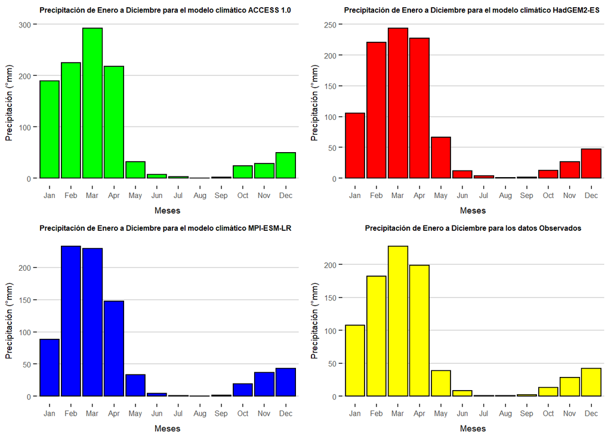

```r
#Crearemos un tema para los títulos y subtitulos de las gráficos:
My_Theme = theme(
  axis.title.x = element_text(size = 7),
  axis.title.y = element_text(size = 7),
  axis.text.x = element_text(size = 6),
  axis.text.y = element_text(size = 6),
  plot.title = element_text(size=rel(0.5), #Tamaño relativo de la letra del título
                            vjust=2, #Justificación vertical, para separarlo del gráfico
                            face="bold",#Letra negrilla
                            color="black", #Color del texto
                            lineheight=1.2)) #Separación entre líneas

#Para el gráfico del modelo climático ACCESS 1.0:
g1<-ggplot(Sesgo_p, aes(Meses, `ACCESS 1.0`)) +
  geom_bar(stat = "identity", fill = "green",colour="black")+
  labs(y="Precipitación (°mm)", x = "Meses")+
  My_Theme+
  scale_x_discrete(labels = month.abb)+
  ggtitle("Precipitación de Enero a Diciembre para el modelo climático ACCESS 1.0")+
  theme(plot.title = element_text(vjust = 1, hjust = 0.3))+
  theme(axis.title.y = element_text(vjust = 2))+
  theme(axis.title.x = element_text(vjust = -1))+
  theme_hc()

#Para el gráfico del modelo climático HadGEM2-ES:
g2<-ggplot(Sesgo_p, aes(Meses, `HadGEM2-ES`)) +
  geom_bar(stat = "identity", fill = "red",colour="black")+
  My_Theme+
  scale_x_discrete(labels = month.abb)+
  labs(y="Precipitación (°mm)", x = "Meses")+
  ggtitle("Precipitación de Enero a Diciembre para el modelo climático HadGEM2-ES")+
  theme(plot.title = element_text(vjust = 1, hjust = 0.3))+
  theme(axis.title.y = element_text(vjust = 2))+
  theme(axis.title.x = element_text(vjust = -1))+
  theme_hc()

#Para el gráfico del modelo climático MPI-ESM-LR:
g3<-ggplot(Sesgo_p, aes(Meses, `MPI-ESM-LR`)) +
  geom_bar(stat = "identity", fill = "blue",colour="black")+
  My_Theme+
  scale_x_discrete(labels = month.abb)+
  labs(y="Precipitación (°mm)", x = "Meses")+
  ggtitle("Precipitación de Enero a Diciembre para el modelo climático MPI-ESM-LR")+
  theme(plot.title = element_text(vjust = 1, hjust = 0.3))+
  theme(axis.title.y = element_text(vjust = 2))+
  theme(axis.title.x = element_text(vjust = -1))+
  theme_hc()

#Para el gráfico de los datos Observados:
g4<-ggplot(Sesgo_p, aes(Meses, Observado)) +
  geom_bar(stat = "identity", fill = "yellow", colour="black")+
  scale_x_discrete(labels = month.abb)+
  labs(y="Precipitación (°mm)", x = "Meses")+
  ggtitle("Precipitación de Enero a Diciembre para los datos Observados")+
  My_Theme+
  theme(plot.title = element_text(vjust = 1, hjust = 0.5))+
  theme(axis.title.y = element_text(vjust = 2))+
  theme(axis.title.x = element_text(vjust = -1))+
  theme_hc()

#Lo agruparemos en un solo gráfico mediante la librería ggpubr
require(ggpubr)
ggpubr::ggarrange(g1,g2,g3,g4)
```

Así mismo, podemos realizar los gráficos de forma lineal:

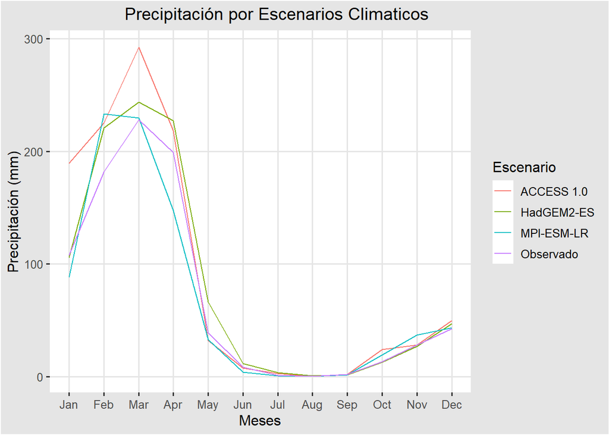

```r
ggplot(datos,aes(x=Meses, y=Precipitacion,color=Escenario))+
  geom_line(aes(x=Meses, y=Precipitacion,color=Escenario))+
  ggtitle("               Precipitación por Escenarios Climaticos")+
  xlab("Meses") + ylab("Precipitación (mm)")+
  theme(plot.title = element_text(vjust = 1, hjust = 0.5))+
  theme(axis.title.y = element_text(vjust = 3))+
  theme(axis.title.x = element_text(vjust = -1))+
  theme_igray()+
  scale_x_continuous(breaks = c(1:12), labels = month.abb)
```

*INTERPRETACIÓN*

Como observamos en el gráfico, el mes de marzo presenta la mayor precipitación para el escenario climático ACCESS 1.0, alejándose del valor de los datos observados,mientras que el escenario climático MPI-ESM-LR presenta un valor de precipitación similar a los datos observados para dicho mes. La mayor similitud de todos los escenarios climáticos con respecto a los datos observados ocurren en los meses de Agosto y Setiembre, siendo meses de poca precipitación.

Adicionalmente se realizará un gráfico para cada variable en función a los escenarios climáticos y datos observados:

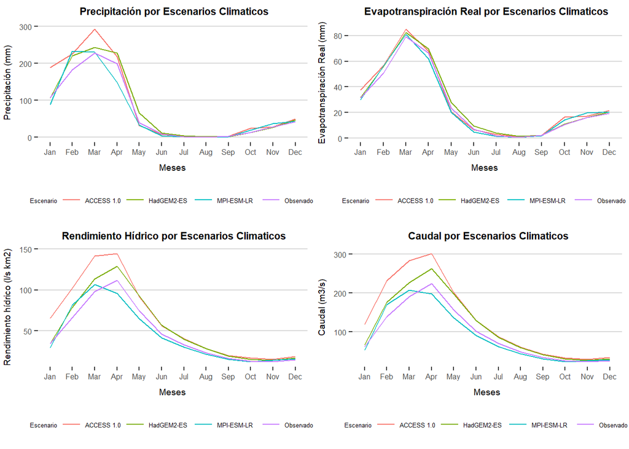

```r
#Crearemos un tema para los títulos y subtitulos de las gráficos:
My_Theme = theme(
  axis.title.x = element_text(size = 7),
  axis.title.y = element_text(size = 7),
  axis.text.x = element_text(size = 6),
  axis.text.y = element_text(size = 6),
  plot.title = element_text(size=rel(0.7), #Tamaño relativo de la letra del título
                            vjust=2, #Justificación vertical, para separarlo del gráfico
                            face="bold",#Letra negrilla
                            color="black", #Color del texto
                            lineheight=1.2), #Separación entre líneas
  legend.title=element_text(size=rel(0.4)),
  legend.text=element_text(size=rel(0.4)))

p1<-ggplot(datos,aes(x=Meses, y=Precipitacion,color=Escenario))+
  geom_line(aes(x=Meses, y=Precipitacion,color=Escenario))+
  ggtitle(" Precipitación por Escenarios Climaticos")+
  My_Theme+
  xlab("Meses") + ylab("Precipitación (mm)")+
  theme(plot.title = element_text(vjust = 1, hjust = 0.5))+
  theme(axis.title.y = element_text(vjust = 3))+
  theme(axis.title.x = element_text(vjust = -1))+
  theme_hc()+
  scale_x_continuous(breaks = c(1:12), labels = month.abb)

p2<-ggplot(datos,aes(x=Meses, y=ETR,color=Escenario))+
  geom_line(aes(x=Meses, y=ETR,color=Escenario))+
  ggtitle(" Evapotranspiración Real por Escenarios Climaticos")+
  My_Theme+
  xlab("Meses") + ylab("Evapotranspiración Real (mm)")+
  theme(plot.title = element_text(vjust = 1, hjust = 0.5))+
  theme(axis.title.y = element_text(vjust = 3))+
  theme(axis.title.x = element_text(vjust = -1))+
  theme_hc()+
  scale_x_continuous(breaks = c(1:12), labels = month.abb)

p3<-ggplot(datos,aes(x=Meses, y=Rendimientoh,color=Escenario))+
  geom_line(aes(x=Meses, y=Rendimientoh,color=Escenario))+
  ggtitle(" Rendimiento Hídrico por Escenarios Climaticos")+
  My_Theme+
  xlab("Meses") + ylab("Rendimiento hídrico (l/s km2)")+
  theme(plot.title = element_text(vjust = 1, hjust = 0.5))+
  theme(axis.title.y = element_text(vjust = 3))+
  theme(axis.title.x = element_text(vjust = -1))+
  theme_hc()+
  scale_x_continuous(breaks = c(1:12), labels = month.abb)

p4<-ggplot(datos,aes(x=Meses, y=Caudal,color=Escenario))+
  geom_line(aes(x=Meses, y=Caudal,color=Escenario))+
  ggtitle(" Caudal por Escenarios Climaticos")+
  My_Theme+
  xlab("Meses") + ylab("Caudal (m3/s)")+
  theme(plot.title = element_text(vjust = 1, hjust = 0.5))+
  theme(axis.title.y = element_text(vjust = 3))+
  theme(axis.title.x = element_text(vjust = -1))+
  theme_hc()+
  scale_x_continuous(breaks = c(1:12), labels = month.abb)

#Lo agruparemos en un solo gráfico mediante la librería ggpubr
require(ggpubr)
ggpubr::ggarrange(p1,p2,p3,p4)
```

## Parte 03

*Se tiene el conjunto de datos de temperatura diaria (periodo 1928 - 2015) de ciertas estaciones meteorológicas (temperatureDataset.csv), donde cada una de estas están asociadas a un código unico (p.e. qc00000208). Si existen valores iguales a -99.9, considerarlos como missing values y convertirlos a NA*

```r
library(tidyverse)
DatosT <-
  read.csv("https://raw.githubusercontent.com/DeysyCondor/R_2021/master/temperatureDataset.csv") %>%
  tibble() %>%
  dplyr::select(DATE, qc00000441) %>%
  rename( Temp = qc00000441) %>%
  mutate( DATE = as.Date(DATE, format = "%d/%m/%Y")) %>%
  arrange(DATE) %>%
  mutate( Temp = ifelse(Temp == -99.9, NA, Temp))

DatosT
```

```
## # A tibble: 31,775 x 2
##    DATE        Temp
##    <date>     <dbl>
##  1 1928-11-02    NA
##  2 1928-11-03    NA
##  3 1928-11-04    NA
##  4 1928-11-05    NA
##  5 1928-11-06    NA
##  6 1928-11-07    NA
##  7 1928-11-08    NA
##  8 1928-11-09    NA
##  9 1928-11-10    NA
## 10 1928-11-11    NA
## # ... with 31,765 more rows
```

Comprobando que la cantidad de datos se encuentren completas:

```r
A<-seq(as.Date("1928-11-02"), as.Date("2015-10-31"), by = "day") %>% length()


B<-nrow(DatosT)


A==B
```

```
## [1] TRUE
```

**3.1** *Determine la cantidad de missing values para los años hidrologicos Sep1983-Agos1984 y Sep1997- Agos1998*

Primero creamos una columna que nos indica si los datos presentan missing values, el cuál considera que si el valor resulta “FALSE”, no contiene ningún missing values, en cambio si resulta “TRUE”, presentan missing values.

```r
DatosT1 <-
  DatosT %>%
  dplyr::filter(
    DATE >="1983-09-01" & DATE <= "1984-08-31" |
    DATE >="1997-09-01" & DATE <= "1998-08-31"
    ) %>%
  mutate(missVal = sum(is.na(Temp))) #En missVal nos aparece que existe 1 solo NA
DatosT1
```

```
## # A tibble: 731 x 3
##    DATE        Temp missVal
##    <date>     <dbl>   <int>
##  1 1983-09-01  24.6       1
##  2 1983-09-02  23         1
##  3 1983-09-03  23.6       1
##  4 1983-09-04  20         1
##  5 1983-09-05  22.6       1
##  6 1983-09-06  23         1
##  7 1983-09-07  20         1
##  8 1983-09-08  22         1
##  9 1983-09-09  20         1
## 10 1983-09-10  22         1
## # ... with 721 more rows
```

Para determinar en que fecha se encuentra exactamente, es de la siguiente manera:

```r
#De esta manera nos sale cuál es exactamente ese NA:
DatosT1 <-
  DatosT %>%
  dplyr::filter(
    (DATE >= "1983-10-01" & DATE <= "1984-08-01") |
      (DATE >= "1997-10-01" & DATE <= "1998-08-01")
  ) %>%
  mutate(missVal = is.na(Temp)) %>%
  dplyr::filter(
    missVal == "TRUE"
  )

DatosT1
```

```
## # A tibble: 1 x 3
##   DATE        Temp missVal
##   <date>     <dbl> <lgl>
## 1 1984-01-28    NA TRUE
```

**3.2** *Calcule la serie de tiempo de temperatura mensual (si el de dias con missing values, en un mes, supera el 5%, la temperatura mensual sera considerado como un NA). Ademas, identifique, visualmente, posibles valores atipicos y describa una posible causa*

```r
DatosT2 <-
  DatosT %>%
  group_by( DATE = str_sub(DATE, 1, 7)) %>%
  mutate(
    missVal = sum(is.na(Temp) * 100 / n()) #Para calcular % de NA por mes
  ) %>%
  summarize(
    Tmonth = mean(Temp, na.rm = T),
    missVal = unique(missVal) #Se convierte a paso mensual
  ) %>%
  mutate(
  Tmonth = ifelse(missVal >= 5, NA, Tmonth), #1
  DATE = as.Date(sprintf("%1$s-01", DATE)),
  Month = str_sub(DATE, 6, 7)
 )

DatosT2
```

```
## # A tibble: 1,044 x 4
##    DATE       Tmonth missVal Month
##    <date>      <dbl>   <dbl> <chr>
##  1 1928-11-01     NA     100 11
##  2 1928-12-01     NA     100 12
##  3 1929-01-01     NA     100 01
##  4 1929-02-01     NA     100 02
##  5 1929-03-01     NA     100 03
##  6 1929-04-01     NA     100 04
##  7 1929-05-01     NA     100 05
##  8 1929-06-01     NA     100 06
##  9 1929-07-01     NA     100 07
## 10 1929-08-01     NA     100 08
## # ... with 1,034 more rows
```

Graficándolo:

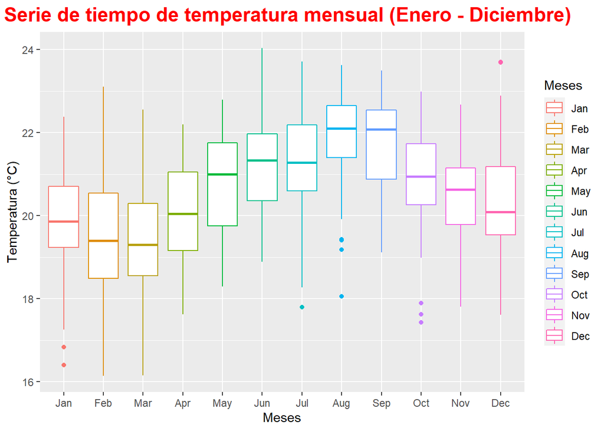

```r
library(ggthemes)

Grafico <-ggplot(data = DatosT2, mapping = aes(x = Month, y = Tmonth,color = Month))+
  geom_boxplot() +
  ggtitle("  Serie de tiempo de temperatura mensual (Enero - Diciembre)")+
  xlab("Meses") + ylab("Temperatura (°C)") +
  theme (plot.title = element_text(family="Comic Sans MS",size=rel(1.5),hjust = 0.5,
                                   face="bold", color="red", lineheight=0.5))+
  scale_x_discrete(labels = month.abb,name="Meses")+
  scale_color_discrete(labels= month.abb,name="Meses")

plot(Grafico)
```

**INTERPRETACIÓN** Los valores atípicos son valores en el que estadisticamente se alejan de cierto rango; en el ploteo, los puntos atípicos se encuentran entre los meses de Enero, Julio, Agosto, Octubre y Diciembre, debido a que son los meses de periodo de cambio de estación, por lo que es común ver esos tipos de anomalías de temperatura ciertos días, ya que son periodos en el que se está estableciendo la estación por lo que existe cambio graduales de frío y calor como forma de transición.

**3.3** *Determine la cantidad de missing values de la serie de tiempo a paso mensual para los años 2005 y 2010.*

Primero creamos una columna (missVal5_10) que nos indica si los datos presentan missing values, el cuál considera que si el valor resulta “FALSE”, no contiene ningún missing values, en cambio si resulta “TRUE”, presentan missing values.

```r
DatosT3 <-
  DatosT2 %>%
  dplyr::filter(
    (DATE >="2005-01-01" & DATE <= "2005-12-01") |
    (DATE >="2010-01-01" & DATE <= "2010-12-01")
  ) %>%
  mutate(missVal5_10 = sum(is.na(Tmonth))) #Nos aparece que existe 4 solo NA's

DatosT3
```

```
## # A tibble: 24 x 5
##    DATE       Tmonth missVal Month missVal5_10
##    <date>      <dbl>   <dbl> <chr>       <int>
##  1 2005-01-01   20.4     0   01              4
##  2 2005-02-01   20.9     0   02              4
##  3 2005-03-01   18.5     0   03              4
##  4 2005-04-01   20.2     0   04              4
##  5 2005-05-01   21.1     0   05              4
##  6 2005-06-01   21.7     0   06              4
##  7 2005-07-01   22.4     0   07              4
##  8 2005-08-01   22.3     0   08              4
##  9 2005-09-01   NA      16.7 09              4
## 10 2005-10-01   NA     100   10              4
## # ... with 14 more rows
```

Para determinar en que fecha se encuentra exactamente, es de la siguiente manera:

```r
#De esta manera nos sale cuáles son exactamente:
DatosT3 <-
  DatosT2 %>%
  dplyr::filter(
    (DATE >="2005-01-01" & DATE <= "2005-12-01") |
      (DATE >="2010-01-01" & DATE <= "2010-12-01")
  ) %>%
  mutate(missVal5_10 = is.na(Tmonth)) %>%
  dplyr::filter(
    missVal5_10 == "TRUE"
  )

DatosT3
```

```
## # A tibble: 4 x 5
##   DATE       Tmonth missVal Month missVal5_10
##   <date>      <dbl>   <dbl> <chr> <lgl>
## 1 2005-09-01     NA    16.7 09    TRUE
## 2 2005-10-01     NA   100   10    TRUE
## 3 2005-11-01     NA   100   11    TRUE
## 4 2005-12-01     NA   100   12    TRUE
```

**3.4** *Cree una función que calcule, a partir de los datos de temperatura mensual, la climatología (Ene-Dic).Obtener la climatología para los periodos 1980-1995 y 1996-2010.Plotear sus resultados en una sola gráfica para describir sus diferencias y/o similitudes (entre climatologías)*

```r
Climatologia <-function(Amin,Amax){
  dplyr::filter(DatosT2,str_sub(DATE,1,4) >= Amin & str_sub(DATE,1,4) <=Amax)  %>%
  mutate(mes = str_sub(DATE,6,7)) %>%
  group_by(mes) %>%
  summarise(temperatura = mean(Tmonth,na.rm = TRUE)) %>%
  mutate(mes = month.abb) %>%
  mutate(mes = factor(mes,levels=month.abb))
}
```

Para el periodo de 1980 a 1995:

```r
Climatologia(1980,1995)
```

```
## # A tibble: 12 x 2
##    mes   temperatura
##    <fct>       <dbl>
##  1 Jan          20.6
##  2 Feb          20.4
##  3 Mar          20.4
##  4 Apr          20.8
##  5 May          21.5
##  6 Jun          21.8
##  7 Jul          22.1
##  8 Aug          22.4
##  9 Sep          22.5
## 10 Oct          21.6
## 11 Nov          21.1
## 12 Dec          21.2
```

Para el periodo de 1996 a 2010:

```r
Climatologia(1996,2010)
```

```
## # A tibble: 12 x 2
##    mes   temperatura
##    <fct>       <dbl>
##  1 Jan          19.9
##  2 Feb          19.6
##  3 Mar          19.4
##  4 Apr          20.2
##  5 May          21.1
##  6 Jun          21.4
##  7 Jul          21.6
##  8 Aug          22.1
##  9 Sep          21.9
## 10 Oct          21.0
## 11 Nov          20.5
## 12 Dec          20.1
```

Para plotearlo cada periodo pedido

```r
library(ggplot2)
library(ggthemes)
Graf1<-ggplot(Climatologia(1980,1995), aes(mes, temperatura)) +
  geom_bar(stat = "identity", fill = "blue")+
  scale_x_discrete(labels = month.abb)+
  labs(y="Temperatura (°C)", x = "Meses")+
  ggtitle("Climatología de Enero a Diciembre para los períodos de 1980-1995")+
  theme(plot.title = element_text(vjust = 1, hjust = 0.3))+
  theme(axis.title.y = element_text(vjust = 2))+
  theme(axis.title.x = element_text(vjust = -1))+
  theme_hc()

Graf2<-ggplot(Climatologia(1996,2010), aes(mes, temperatura)) +
  geom_bar(stat = "identity", fill = "green")+
  scale_x_discrete(labels = month.abb)+
  labs(y="Temperatura (°C)", x = "Meses")+
  ggtitle("Climatología de Enero a Diciembre para los períodos de 1996-2010")+
  theme(plot.title = element_text(vjust = 1, hjust = 0.3))+
  theme(axis.title.y = element_text(vjust = 2))+
  theme(axis.title.x = element_text(vjust = -1))+
  theme_hc()
```

Ploteando:

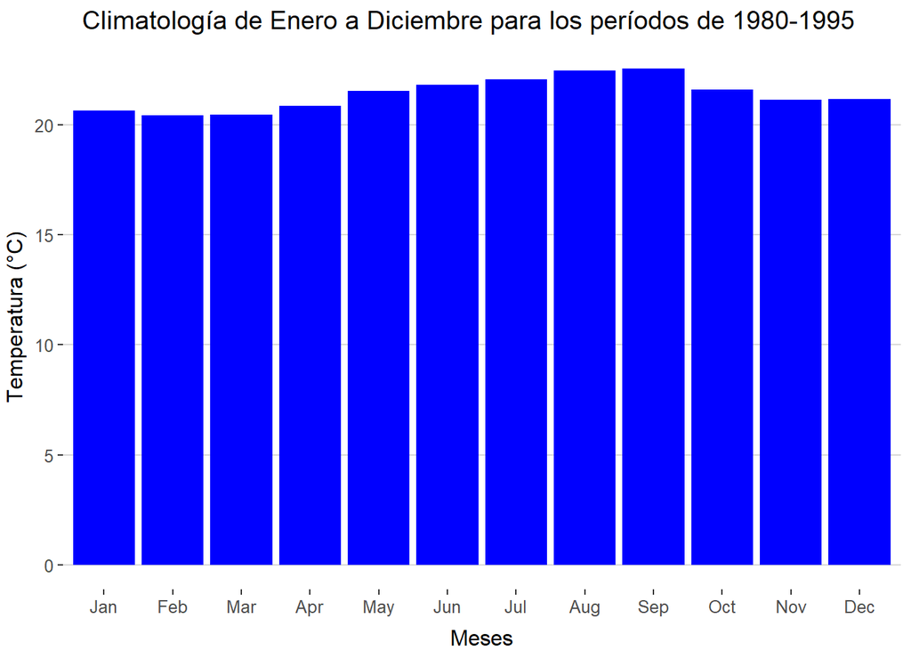

```r
plot(Graf1)
```

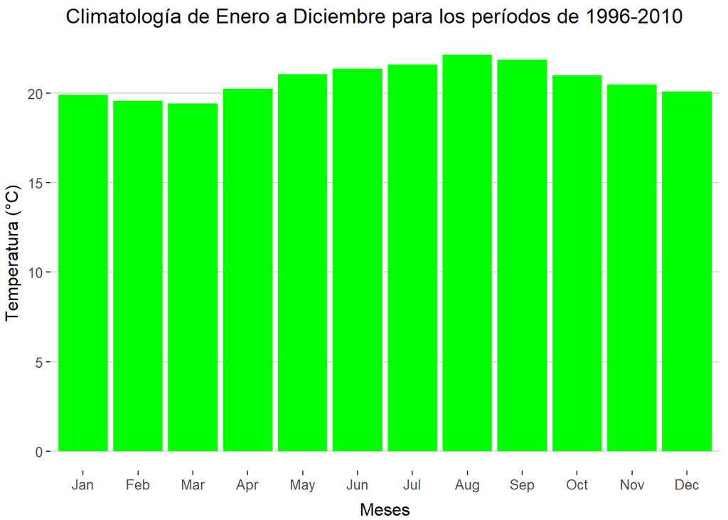

```r
plot(Graf2)
```

Ahora en un solo gráfico:

```r
ETAPA1 <- DatosT2 %>%
  filter(DATE >= "1980-01-01" & DATE < "1995-12-31")%>%
  group_by(Month) %>% summarise(temperatura = mean(Tmonth,na.rm = TRUE),Periodo = "1980-1995")
ETAPA2 <- DatosT2 %>%
  filter(DATE >= "1996-01-01" & DATE < "2010-12-31")%>%
  group_by(Month) %>% summarise(temperatura = mean(Tmonth,na.rm = TRUE),Periodo = "1996-2010")


DF2 <- rbind(ETAPA1,ETAPA2)
DF2
```

```
## # A tibble: 24 x 3
##    Month temperatura Periodo
##    <chr>       <dbl> <chr>
##  1 01           20.6 1980-1995
##  2 02           20.4 1980-1995
##  3 03           20.4 1980-1995
##  4 04           20.8 1980-1995
##  5 05           21.5 1980-1995
##  6 06           21.8 1980-1995
##  7 07           22.1 1980-1995
##  8 08           22.4 1980-1995
##  9 09           22.5 1980-1995
## 10 10           21.6 1980-1995
## # ... with 14 more rows
```

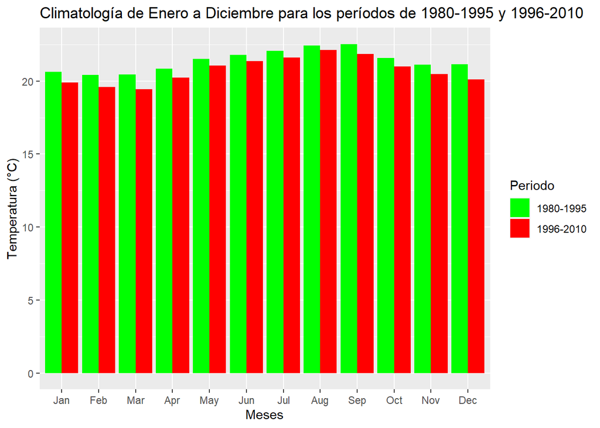

```r
ggplot(data = DF2,aes(x = Month, y = temperatura, fill = Periodo)) +
  geom_bar(stat="identity", position=position_dodge())+
  scale_fill_manual(values=c("green", "red"))+
  scale_x_discrete(labels = month.abb)+
  labs(y="Temperatura (°C)", x = "Meses")+
  ggtitle("Climatología de Enero a Diciembre para los períodos de 1980-1995 y 1996-2010")+
  theme(plot.title = element_text(vjust = 1, hjust = 0.3))+
  theme(axis.title.y = element_text(vjust = 2))+
  theme(axis.title.x = element_text(vjust = -1))+
  theme_gray()
```

Segunda forma de solucionarlo:

```r
Climatologia <- function(Amin, Amax, Bmin, Bmax) {
  dplyr::filter(DatosT2, (DATE >= Amin & DATE <=Amax) |
                  (DATE >= Bmin & DATE <=Bmax)
                ) %>%
  mutate(
    Periodo = ifelse(DATE >= "1980-01-01" & DATE <="1995-12-01", "Periodo1", "Periodo2"),
  ) %>%
  group_by(Periodo, Month) %>%
  summarize(Temp_month = mean(Tmonth, na.rm = T)) %>%
  mutate(Meses = month.abb)
}
```

Para ambos periodos:

```r
X <- Climatologia("1980-01-01","1995-12-01","1996-01-01" ,"2010-12-01")
X
```

```
## # A tibble: 24 x 4
## # Groups:   Periodo [2]
##    Periodo  Month Temp_month Meses
##    <chr>    <chr>      <dbl> <chr>
##  1 Periodo1 01          20.6 Jan
##  2 Periodo1 02          20.4 Feb
##  3 Periodo1 03          20.4 Mar
##  4 Periodo1 04          20.8 Apr
##  5 Periodo1 05          21.5 May
##  6 Periodo1 06          21.8 Jun
##  7 Periodo1 07          22.1 Jul
##  8 Periodo1 08          22.4 Aug
##  9 Periodo1 09          22.5 Sep
## 10 Periodo1 10          21.6 Oct
## # ... with 14 more rows
```

Gráfico:

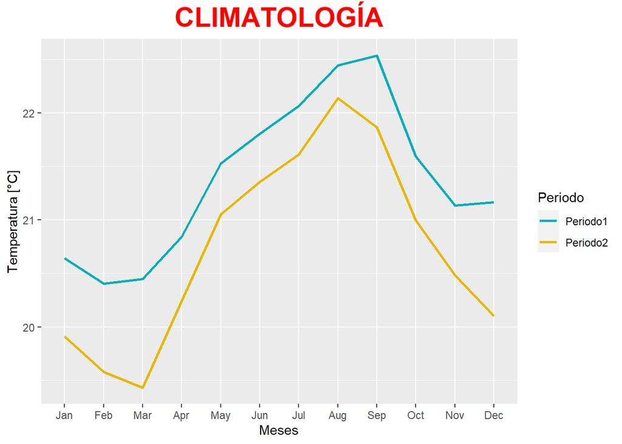

```r
Grafclim <- ggplot(data = X,
                   mapping = aes(x = Month, y = Temp_month, group=Periodo)) +
  geom_line(aes(color = Periodo), size = 1) +
  ggtitle("CLIMATOLOGÍA")+
  theme (plot.title = element_text(family="Comic Sans MS",size=rel(2),hjust = 0.5,
                                   face="bold", color="red", lineheight=1.5))+
  scale_color_manual(values = c("#00AFBB", "#E7B800")) +
  xlab("Meses") + ylab("Temperatura [°C]")+
  scale_x_discrete(labels = month.abb,name="Meses")
Grafclim
```

Tercera forma de solucionarlo (sin función):

Periodo 1:

```r
Periodo1 <-
  DatosT2 %>%
  dplyr::filter(
    (DATE >= "1980-01-01" & DATE <= "1995-12-01")
  ) %>%
  group_by(Month) %>%
  summarize(Temp_month1 = mean(Tmonth, na.rm = T)) %>%
  mutate(
    Periodo = "Periodo1"
  )

Periodo1
```

```
## # A tibble: 12 x 3
##    Month Temp_month1 Periodo
##    <chr>       <dbl> <chr>
##  1 01           20.6 Periodo1
##  2 02           20.4 Periodo1
##  3 03           20.4 Periodo1
##  4 04           20.8 Periodo1
##  5 05           21.5 Periodo1
##  6 06           21.8 Periodo1
##  7 07           22.1 Periodo1
##  8 08           22.4 Periodo1
##  9 09           22.5 Periodo1
## 10 10           21.6 Periodo1
## 11 11           21.1 Periodo1
## 12 12           21.2 Periodo1
```

Periodo2:

```r
Periodo2 <-
  DatosT2 %>%
  dplyr::filter(
    (DATE >= "1996-01-01" & DATE <= "2010-12-01")
  ) %>%
  group_by(Month) %>%
  summarize(Temp_month2 = mean(Tmonth, na.rm = T)) %>%
  mutate(
    Periodo = "Periodo2"
  )

Periodo2
```

```
## # A tibble: 12 x 3
##    Month Temp_month2 Periodo
##    <chr>       <dbl> <chr>
##  1 01           19.9 Periodo2
##  2 02           19.6 Periodo2
##  3 03           19.4 Periodo2
##  4 04           20.2 Periodo2
##  5 05           21.1 Periodo2
##  6 06           21.4 Periodo2
##  7 07           21.6 Periodo2
##  8 08           22.1 Periodo2
##  9 09           21.9 Periodo2
## 10 10           21.0 Periodo2
## 11 11           20.5 Periodo2
## 12 12           20.1 Periodo2
```

Gráfico:

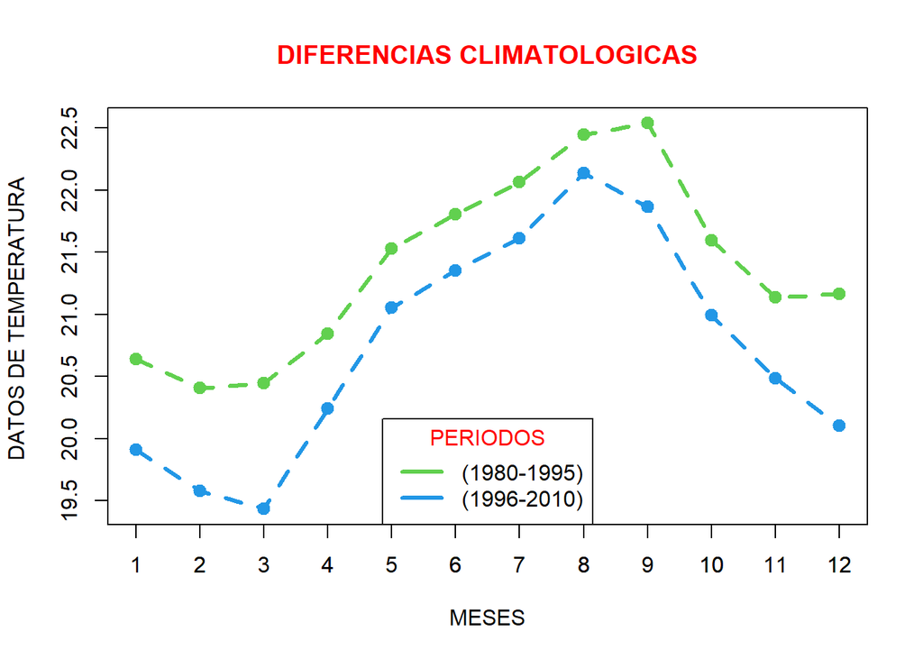

```r
Clim <-
  cbind(Periodo1, Periodo2)


library(dplyr)
Clima <-
  Clim %>% subset(select = !duplicated(names(.)))
Mes <-c(1:12)
Clima2 <- Clima[, c(2 ,4)]
matplot(Clima2, type = "o", lty = 2, pch = 19,lwd=3, main = "DIFERENCIAS CLIMATOLOGICAS",col = 3:4,
        inset = 0.05, col.main="red",
        ylab = "DATOS DE TEMPERATURA ", xlab = "MESES",
        ylim = c(min(Clima2), max(Clima2)))
axis(1, at = seq(round(min(Mes)), round(max(Mes)), by = 1), labels = 1:12)
legend("bottom", legend = c("(1980-1995)", "(1996-2010)"),lwd=3,
       lty = 1, col = 3:4, title = "PERIODOS", title.col = "RED")
```

**INTERPRETACIÓN**

El gráfico muestra el promedio de todos los meses desde Enero hasta Diciembre en los periodos de 1980-1995 y 1996-2010; el comportamiento de la gráfica es similar en ambos comenzando con bajas temperaturas y aumentando gradualmente. Se ve el cambio en que el periodo de 1996 - 2010 las temperaturas son mas frías que periodo 1980 - 1995 y a lo largo de la comparacion la grafica no se cruzan, lo que quiera decir que esa tendencia de bajas temperaturas se dio a lo largo de todo el año incluso en los meses de verano.

**3.5** *Plotear (boxplot) la variabilidad de los valores mensuales (Ene-Dic) para el periodo 1980-2013 y describirlo correctamente.*

Procederemos a plotearlo usando la librería “ggplot”

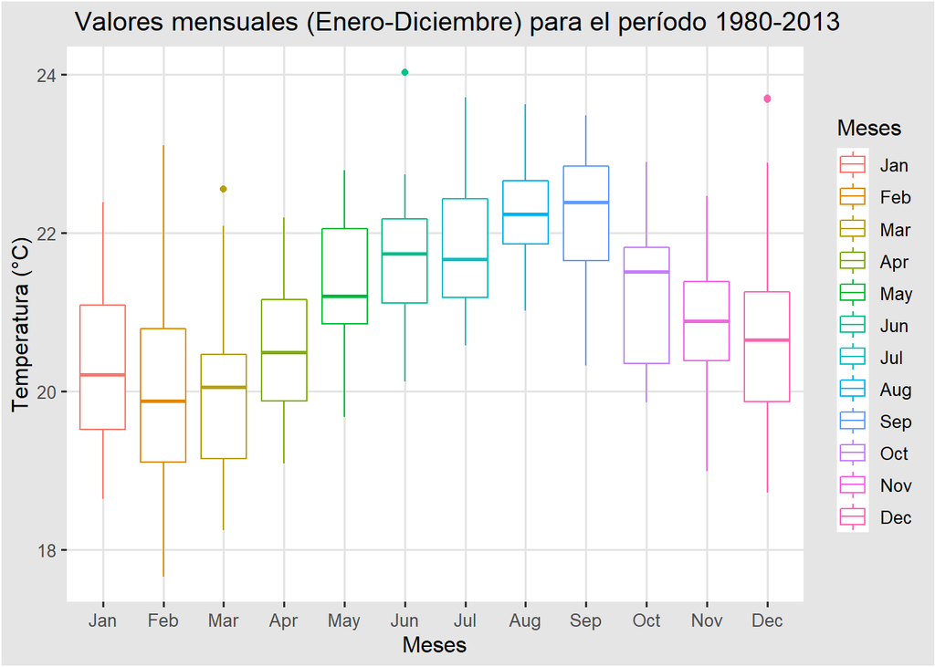

```r
Graf3<-ggplot(dplyr::filter(DatosT2, DATE >= "1980-01-01" & DATE <= "2013-12-31"))+
  geom_boxplot( aes(x=Month,y=Tmonth, color = Month))+
  ggtitle(" Valores mensuales (Enero-Diciembre) para el período 1980-2013")+
  xlab("Meses") + ylab("Temperatura (°C)") +
  theme_igray()+
  scale_x_discrete(labels = month.abb,name="Meses")+
  scale_color_discrete(labels= month.abb,name="Meses")

plot(Graf3)
```

**Otra manera de resolverlo:**

Filtramos el periodo 1980 - 2013:

```r
DatosT10 <-
  DatosT2 %>%
  dplyr::filter(
    DATE >= "1980-01-01" & DATE <= "2013-12-01"
  )

DatosT10
```

```
## # A tibble: 408 x 4
##    DATE       Tmonth missVal Month
##    <date>      <dbl>   <dbl> <chr>
##  1 1980-01-01   20.6       0 01
##  2 1980-02-01   21.0       0 02
##  3 1980-03-01   20.7       0 03
##  4 1980-04-01   21.1       0 04
##  5 1980-05-01   22.1       0 05
##  6 1980-06-01   22.3       0 06
##  7 1980-07-01   21.6       0 07
##  8 1980-08-01   22.2       0 08
##  9 1980-09-01   22.9       0 09
## 10 1980-10-01   20.3       0 10
## # ... with 398 more rows
```

Gráfico:

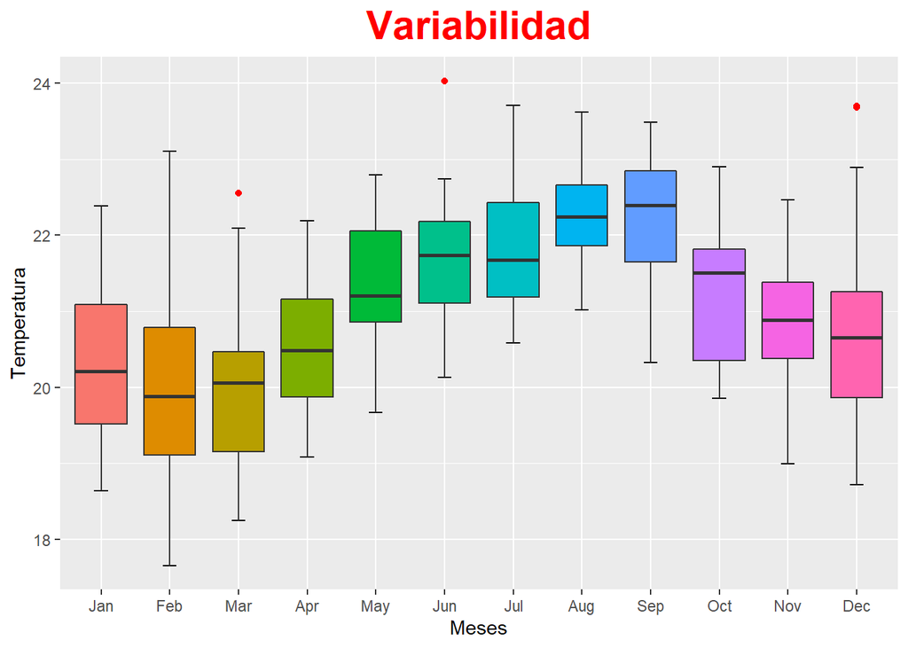

```r
Grafico2 <-ggplot(data = DatosT10, mapping = aes(x = Month, y = Tmonth, fill=Month)) +
  stat_boxplot(geom = "errorbar",
               width = 0.2) +guides(fill=FALSE) +
  geom_boxplot(outlier.colour = "red") + ggtitle("Variabilidad")+
  theme (plot.title = element_text(family="Comic Sans MS",size=rel(2),hjust = 0.5,
                                   face="bold", color="red", lineheight=1.5))+
  xlab("Meses") + ylab("Temperatura") +
  scale_x_discrete(labels = month.abb,name="Meses")+
  scale_color_discrete(labels= month.abb,name="Meses")

Grafico2
```

**INTERPRETACIÓN:**

El gráfico representa un diagrama de caja en el que se encuentra la cantidad de temperatura promedio mensual desde 1980 hasta 2013, siendo los primeros meses los que tienen la más baja temperatura y aumentando con el tiempo en la varianza, el mes de febrero presenta mayor diferencia de temperaturas en relación a los otros meses. Los puntos rojos representan valores atipicos considerados fuera del rango, entre los meses de Mayo hasta octubre represtan las más altas temperaturas a mediados del año, la mediana en la mayoria de meses es irregular y los meses de cambio de estación presenta un mayor volumen en el promedio calculado de todos los años.